# Cars 4 U

### Problem:

Cars4U is a new tech start-up aiming to get a foothold in the pre-owned car market. As there is a slowdown in the sale of new cars in recent years (2018-2019) there has been a shift towards the pre-owned car market in India. The problem is that Unlike new cars, where price and supply are fairly deterministic and managed by OEMs (Original Equipment Manufacturer / except for dealership level discounts which come into play only in the last stage of the customer journey), used cars are very different with huge uncertainty in both pricing and supply.

Thus, Cars4U is in need of a pricing model that can effectively predict the price of used cars and can help the business in devising profitable strategies using differential pricing.

### Questions to be Answered:

We will Explore and visualize the dataset.

Build a linear regression model to predict the prices of used cars.

And Generate a set of insights and recommendations that will help the business.

### Data Dictionary:

S.No.: Serial Number

Name: Name of the car which includes Brand name and Model name

Location: The location in which the car is being sold or is available for purchase Cities

Year: Manufacturing year of the car

Kilometers_driven: The total kilometers driven in the car by the previous owner(s) in KM.

Fuel_Type: The type of fuel used by the car. (Petrol, Diesel, Electric, CNG, LPG)

Transmission: The type of transmission used by the car. (Automatic / Manual)

Owner: Type of ownership

Mileage: The standard mileage offered by the car company in kmpl or km/kg

Engine: The displacement volume of the engine in CC.

Power: The maximum power of the engine in bhp.

Seats: The number of seats in the car.

New_Price: The price of a new car of the same model in INR Lakhs.(1 Lakh = 100, 000)

Price: The price of the used car in INR Lakhs (1 Lakh = 100, 000)

```python
# import all the necessary libraries used for the projects

import pandas as pd # used to manupulate data
import numpy as np # used for manipulating arrays
import matplotlib.pyplot as plt # used for plots and data visualisations
%matplotlib inline
import scipy.stats as stat # used for probability distributions and statistical functions
import seaborn as sns # used for data visualisations
from sklearn.linear_model import LinearRegression #
from sklearn.model_selection import train_test_split #Sklearn package's randomized data splitting function


# Removes the limit from the number of displayed columns and rows.
# This is so I can see the entire dataframe when I print it
       # pd.set_option('display.max_columns', None)
# pd.set_option('display.max_rows', None)
       # pd.set_option('display.max_rows', 200)
```

```python
missing_values = ["NA", "null", "n.a.", "--", "n/a", "Null", "NaN", "NA", "inf)"]


df = pd.read_csv('used_cars_data.csv', na_values = missing_values) # Read the csv files
print(f'There are {df.shape[0]} rows and {df.shape[1]} columns.') # f-string

np.random.seed(1) # Setting a randome seed to get the same random results every time
df.sample(n=10) # Selecting the sample size at 10 for the randome seed`
```

```
There are 7253 rows and 14 columns.
```

|  | S.No. | Name | Location | Year | Kilometers_Driven | Fuel_Type | Transmission | Owner_Type | Mileage | Engine | Power | Seats | New_Price | Price |
| --- | --- | --- | --- | --- | --- | --- | --- | --- | --- | --- | --- | --- | --- | --- |
| 2397 | 2397 | Ford EcoSport 1.5 Petrol Trend | Kolkata | 2016 | 21460 | Petrol | Manual | First | 17.0 kmpl | 1497 CC | 121.36 bhp | 5.0 | 9.47 Lakh | 6.00 |
| 3777 | 3777 | Maruti Wagon R VXI 1.2 | Kochi | 2015 | 49818 | Petrol | Manual | First | 21.5 kmpl | 1197 CC | 81.80 bhp | 5.0 | 5.44 Lakh | 4.11 |
| 4425 | 4425 | Ford Endeavour 4x2 XLT | Hyderabad | 2007 | 130000 | Diesel | Manual | First | 13.1 kmpl | 2499 CC | 141 bhp | 7.0 | NaN | 6.00 |
| 3661 | 3661 | Mercedes-Benz E-Class E250 CDI Avantgrade | Coimbatore | 2016 | 39753 | Diesel | Automatic | First | 13.0 kmpl | 2143 CC | 201.1 bhp | 5.0 | NaN | 35.28 |
| 4514 | 4514 | Hyundai Xcent 1.2 Kappa AT SX Option | Kochi | 2016 | 45560 | Petrol | Automatic | First | 16.9 kmpl | 1197 CC | 82 bhp | 5.0 | NaN | 6.34 |
| 599 | 599 | Toyota Innova Crysta 2.8 ZX AT | Coimbatore | 2019 | 40674 | Diesel | Automatic | First | 11.36 kmpl | 2755 CC | 171.5 bhp | 7.0 | 28.05 Lakh | 24.82 |
| 186 | 186 | Mercedes-Benz E-Class E250 CDI Avantgrade | Bangalore | 2014 | 37382 | Diesel | Automatic | First | 13.0 kmpl | 2143 CC | 201.1 bhp | 5.0 | NaN | 32.00 |
| 305 | 305 | Audi A6 2011-2015 2.0 TDI Premium Plus | Kochi | 2014 | 61726 | Diesel | Automatic | First | 17.68 kmpl | 1968 CC | 174.33 bhp | 5.0 | NaN | 20.77 |
| 4582 | 4582 | Hyundai i20 1.2 Magna | Kolkata | 2011 | 36000 | Petrol | Manual | First | 18.5 kmpl | 1197 CC | 80 bhp | 5.0 | NaN | 2.50 |
| 5434 | 5434 | Honda WR-V Edge Edition i-VTEC S | Kochi | 2019 | 13913 | Petrol | Manual | First | 17.5 kmpl | 1199 CC | 88.7 bhp | 5.0 | 9.36 Lakh | 8.20 |

We will be dropping the S.ID Number column from the data as it serves no real purpose as we can use the index generated by python. We will also be dropping the New Price column as it has many missing values and while it could be useful for genertating insight as to how to price second hand cars, it's not worth it. No other column will be errased as of now.The rest of the colums will be useful for EDA.

There are several columns that should be numeric but might be represented as object types as visible from the 10 rows above. There it can be seen that the columns Mileage, Engine, Power, and New_Price are supposed to represent numeric values but due to the units it is likely represented as a object.

Additionally there is a high probability that there are several columns that have missing values that need to be identified and corrected with either deleting the entry, replacing with the median or mean. This will be identified later on in the process.

```python
df.drop(['S.No.', 'New_Price' ],axis=1,inplace=True) # Drop all the rows that need to be droped from the Database to best focus on the relevent  columns
```

```python
df.info() # Check the data type and see the number of null values for each of the remaining columns.
```

```
<class 'pandas.core.frame.DataFrame'>
RangeIndex: 7253 entries, 0 to 7252
Data columns (total 12 columns):
 #   Column             Non-Null Count  Dtype
---  ------             --------------  -----
 0   Name               7253 non-null   object
 1   Location           7253 non-null   object
 2   Year               7253 non-null   int64
 3   Kilometers_Driven  7253 non-null   int64
 4   Fuel_Type          7253 non-null   object
 5   Transmission       7253 non-null   object
 6   Owner_Type         7253 non-null   object
 7   Mileage            7251 non-null   object
 8   Engine             7207 non-null   object
 9   Power              7207 non-null   object
 10  Seats              7200 non-null   float64
 11  Price              6019 non-null   float64
dtypes: float64(2), int64(2), object(8)
memory usage: 680.1+ KB
```

It is important to note that several of these columns have missing values. They must be corrected to get proper test readings.

Additionally, as previously identified the columns Mileage, Engine and Power are represented as object types insted of int or floats. Thus, these need to be changed to the accurate data type to facilitate doing EDA.

```python
df.isnull().sum().sort_values(ascending=False) #Verify which columns have how many missing values.
```

```
Price                1234
Seats                  53
Engine                 46
Power                  46
Mileage                 2
Name                    0
Location                0
Year                    0
Kilometers_Driven       0
Fuel_Type               0
Transmission            0
Owner_Type              0
dtype: int64
```

Just to confirm, it can be seen that the most missing values come from the Price column. Seats columns' missing values could be due to failure to input the information but can be easily rectified. As for Engine and Power it can be inferred that the missing values from these two columns go hand in hand. As for Mileage the missing values will have to be seen to find the reason.

### Processing columns

I want to get summary statistics and start getting a sense of the distributions of these variables and how they relate to each other, but first I need to turn many of these into numeric columns.

```python
 # use this loop to print the names of the columns where Lakh is used
units = []
for colname in df.columns[df.dtypes == 'object']:  # only need to consider string columns
    if df[colname].str.endswith('Lakh').any():  # using `.str` so I can use an element-wise string method
        units.append(colname)
print(units)
```

```
[]
```

We are already aware that Mileage, Engine, and Power all have units kmpl or km/kg, CC, bhp respectively but it was prudent to check if any other column was represented with Lakh aside from New_Price column.

We will be converting km/kg to kmpl to have equal numeric values and dropping the units of measurement.

We will be getting rid of the CC and bhp to just represent the values as numeric.

We will be identifying and fixing any missing values along the other columns and correcting for outliers

Starting off with deleting the missing values that conside with missing values in Price

```python
df=df.dropna() #Used to drop all missing values that python can identify, preferable to have reliable data than skewed data
```

```python
df.isnull().sum().sort_values(ascending=False) #check if the missing values were deleted
```

```
Name                 0
Location             0
Year                 0
Kilometers_Driven    0
Fuel_Type            0
Transmission         0
Owner_Type           0
Mileage              0
Engine               0
Power                0
Seats                0
Price                0
dtype: int64
```

#### Mileage:

```python
df.Mileage # Looking for the length of the column and how some of the rows look
```

```
0       26.6 km/kg
1       19.67 kmpl
2        18.2 kmpl
3       20.77 kmpl
4        15.2 kmpl
           ...
6014     28.4 kmpl
6015     24.4 kmpl
6016     14.0 kmpl
6017     18.9 kmpl
6018    25.44 kmpl
Name: Mileage, Length: 5975, dtype: object
```

```python
# Will be used to convert the Km/kg and Kmpl to a common numerican value and convert the data type from object to a float

Converted_Mileage= []
for i in df.Mileage:
    if str(i).endswith('km/kg'):
        i = i[:-6]
        i = float(i)*1.40
        Converted_Mileage.append(float(i))
    elif str(i).endswith('kmpl'):
        i = i[:-6]
        Converted_Mileage.append(float(i))
```

```python
df['Mileage']=Converted_Mileage
```

```python
df.Mileage
```

```
0       37.24
1       19.60
2       18.00
3       20.70
4       15.00
        ...
6014    28.00
6015    24.00
6016    14.00
6017    18.00
6018    25.40
Name: Mileage, Length: 5975, dtype: float64
```

#### Engine:

```python
df.Engine # get a view of the Engine data
```

```
0        998 CC
1       1582 CC
2       1199 CC
3       1248 CC
4       1968 CC
         ...
6014    1248 CC
6015    1120 CC
6016    2498 CC
6017     998 CC
6018     936 CC
Name: Engine, Length: 5975, dtype: object
```

```python
df['Engine'] = df['Engine'].str.strip()           #used to get rid of the white space
df['Engine'] = df['Engine'].str.replace('CC', '') #used to get rid of the units CC
```

```python
df['Engine']= df['Engine'].astype(int) #used to change the data type of the column to int format
```

```python
df.Engine #check again to make sure it worked and the column is as we want
```

```
0        998
1       1582
2       1199
3       1248
4       1968
        ...
6014    1248
6015    1120
6016    2498
6017     998
6018     936
Name: Engine, Length: 5975, dtype: int32
```

#### Power:

```python
df.Power # visualise the Power data
```

```
0       58.16 bhp
1       126.2 bhp
2        88.7 bhp
3       88.76 bhp
4       140.8 bhp
          ...
6014       74 bhp
6015       71 bhp
6016      112 bhp
6017     67.1 bhp
6018     57.6 bhp
Name: Power, Length: 5975, dtype: object
```

```python
#Get rid of any possible white spaces and the units bhp from the column
df['Power'] = df['Power'].str.strip()
df['Power'] = df['Power'].str.replace('bhp', '')
```

```python
#Check to make sure all missing values are gone
df['Power'].isnull().sum()
```

```
0
```

There seems to still be variabels in the data that isn't recognized as a null value but needs to be dealt with.

```python
# Used to delete all the values that are writen as Null that might have contained a whitespace value before it that was not caught by the first code
Null_Value = df[ df['Power'] == 'null' ].index
df.drop(Null_Value, inplace=True)
```

Now that we have deleted the rows containing Null values we can convert the column into a float type.

```python
# change the data type to float
df['Power']=df['Power'].astype(float)
```

```python
# used to make sure that all the columns are the right data types before we perform feature engineering and EDA
df.info()
```

```
<class 'pandas.core.frame.DataFrame'>
Int64Index: 5872 entries, 0 to 6018
Data columns (total 12 columns):
 #   Column             Non-Null Count  Dtype
---  ------             --------------  -----
 0   Name               5872 non-null   object
 1   Location           5872 non-null   object
 2   Year               5872 non-null   int64
 3   Kilometers_Driven  5872 non-null   int64
 4   Fuel_Type          5872 non-null   object
 5   Transmission       5872 non-null   object
 6   Owner_Type         5872 non-null   object
 7   Mileage            5872 non-null   float64
 8   Engine             5872 non-null   int32
 9   Power              5872 non-null   float64
 10  Seats              5872 non-null   float64
 11  Price              5872 non-null   float64
dtypes: float64(4), int32(1), int64(2), object(5)
memory usage: 573.4+ KB
```

Now that Engine, Power and Mileage have been converted to the right data type and have been stripped of their unit demarkers and have been converted in the case of Mileage we can focus on Feature engineering and looking at outliers

```python
df.describe().T
```

|  | count | mean | std | min | 25% | 50% | 75% | max |
| --- | --- | --- | --- | --- | --- | --- | --- | --- |
| Year | 5872.0 | 2013.477691 | 3.164568 | 1998.00 | 2012.0000 | 2014.00 | 2016.00 | 2019.000 |
| Kilometers_Driven | 5872.0 | 58316.999149 | 92169.410006 | 171.00 | 33422.5000 | 52609.00 | 72402.75 | 6500000.000 |
| Mileage | 5872.0 | 18.134156 | 4.695584 | 0.00 | 15.0000 | 18.00 | 21.00 | 46.956 |
| Engine | 5872.0 | 1625.745572 | 601.641783 | 624.00 | 1198.0000 | 1495.50 | 1991.00 | 5998.000 |
| Power | 5872.0 | 113.276894 | 53.881892 | 34.20 | 75.0000 | 97.70 | 138.10 | 560.000 |
| Seats | 5872.0 | 5.283719 | 0.805081 | 2.00 | 5.0000 | 5.00 | 5.00 | 10.000 |
| Price | 5872.0 | 9.603919 | 11.249453 | 0.44 | 3.5175 | 5.75 | 10.00 | 160.000 |

```python
num_to_display = 15  # defining number of variables to see
for colname in df.dtypes[df.dtypes == 'object'].index: # Used to display the different non numerical values by column for the defined number of variables
    val_counts = df[colname].value_counts()
    print(val_counts[:num_to_display])
    if len(val_counts) > num_to_display:
        print(f'Only displaying first {num_to_display} of {len(val_counts)} values.')
    print('\n\n')
```

```
Mahindra XUV500 W8 2WD        49
Maruti Swift VDI              45
Honda City 1.5 S MT           34
Maruti Swift Dzire VDI        34
Maruti Ritz VDi               30
Hyundai i10 Sportz            30
Toyota Fortuner 3.0 Diesel    29
Hyundai Grand i10 Sportz      27
Honda Amaze S i-Dtech         27
Honda Brio S MT               25
Maruti Ertiga VDI             25
Honda City 1.5 V MT           24
Hyundai Verna 1.6 SX          23
Maruti Wagon R VXI            23
Maruti Wagon R LXI            22
Name: Name, dtype: int64
Only displaying first 15 of 1811 values.



Mumbai        775
Hyderabad     718
Kochi         645
Coimbatore    629
Pune          594
Delhi         545
Kolkata       521
Chennai       476
Jaipur        402
Bangalore     347
Ahmedabad     220
Name: Location, dtype: int64



Diesel    3152
Petrol    2655
CNG         55
LPG         10
Name: Fuel_Type, dtype: int64



Manual       4170
Automatic    1702
Name: Transmission, dtype: int64



First             4839
Second             925
Third              101
Fourth & Above       7
Name: Owner_Type, dtype: int64
```

It appears that both the numeric and object type data are in order so we can continue. Additionally I choose to keep the Price column untouched with the multiplier of a 100000 so that the numbers remain manageable as we perform EDA.

Though from the innitial view it can be seen that several of these columns might be skewed to the right. It will be prudent to later explore into this.

### Univariate analysis - Bivariate analysis

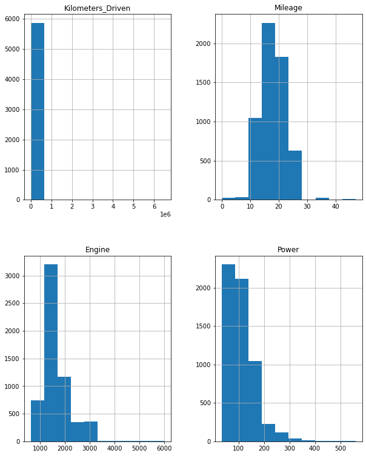

```python
Visual = df[['Kilometers_Driven','Mileage','Engine','Power']]
Visual.hist(sharex=False, sharey=False, figsize =(10,13) )
plt.show()
```

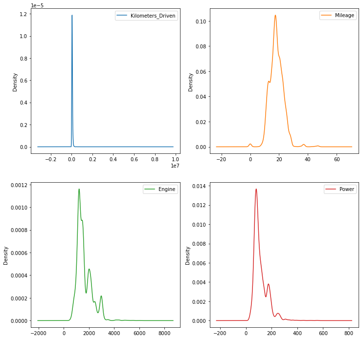

```python
Visual.plot(kind='density', subplots=True, layout=(2,2), sharex=False, legend=True, figsize=(12,12))
plt.show()
```

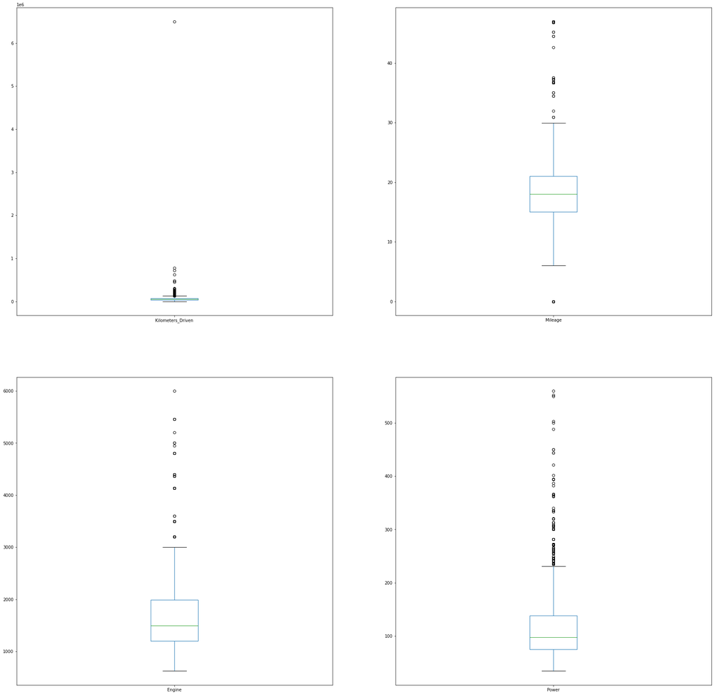

```python
# visualise outliers in the different int columns
Visual.plot(kind='box', subplots=True, layout=(2,2), sharex=False, sharey=False,
figsize = (30, 30))
plt.show()
```

```python
df.describe()
```

|  | Year | Kilometers_Driven | Mileage | Engine | Power | Seats | Price |
| --- | --- | --- | --- | --- | --- | --- | --- |
| count | 5872.000000 | 5.872000e+03 | 5872.000000 | 5872.000000 | 5872.000000 | 5872.000000 | 5872.000000 |
| mean | 2013.477691 | 5.831700e+04 | 18.134156 | 1625.745572 | 113.276894 | 5.283719 | 9.603919 |
| std | 3.164568 | 9.216941e+04 | 4.695584 | 601.641783 | 53.881892 | 0.805081 | 11.249453 |
| min | 1998.000000 | 1.710000e+02 | 0.000000 | 624.000000 | 34.200000 | 2.000000 | 0.440000 |
| 25% | 2012.000000 | 3.342250e+04 | 15.000000 | 1198.000000 | 75.000000 | 5.000000 | 3.517500 |
| 50% | 2014.000000 | 5.260900e+04 | 18.000000 | 1495.500000 | 97.700000 | 5.000000 | 5.750000 |
| 75% | 2016.000000 | 7.240275e+04 | 21.000000 | 1991.000000 | 138.100000 | 5.000000 | 10.000000 |
| max | 2019.000000 | 6.500000e+06 | 46.956000 | 5998.000000 | 560.000000 | 10.000000 | 160.000000 |

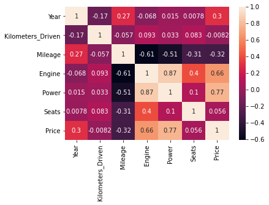

```python
# heatmap to evaluate corrilation between different columns
sns.heatmap(df.corr(method='pearson'),annot=True,)
fig=plt.gcf()
plt.show()
```

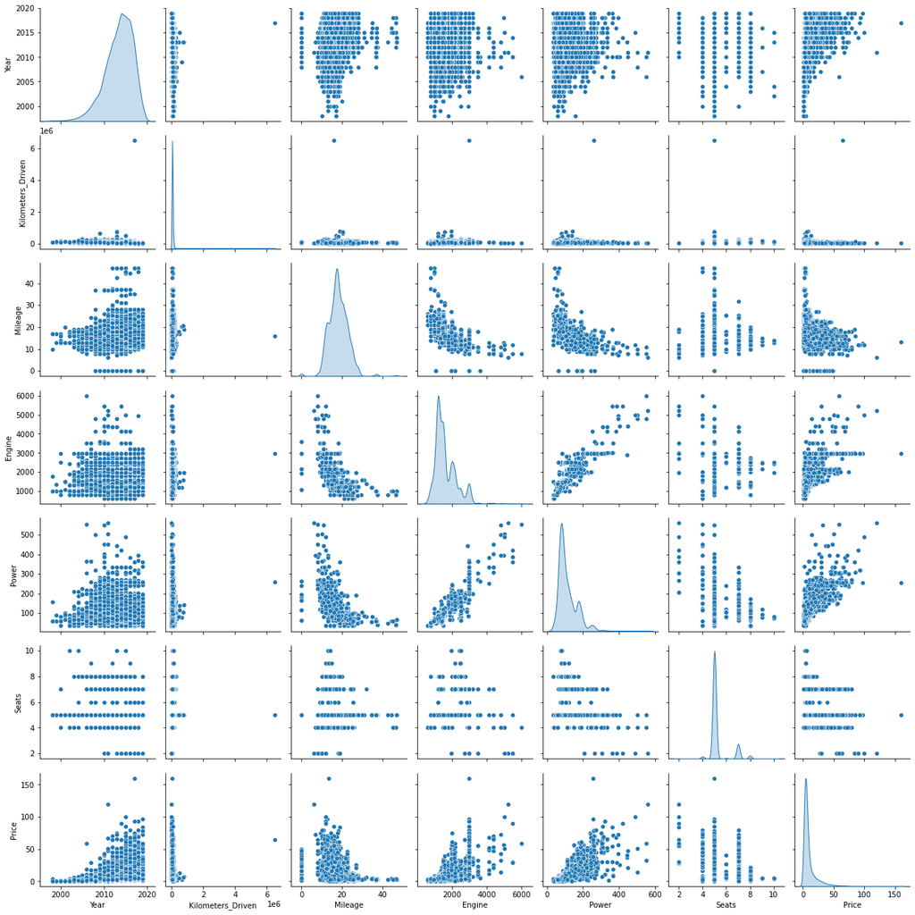

```python
sns.pairplot(df, diag_kind='kde')
```

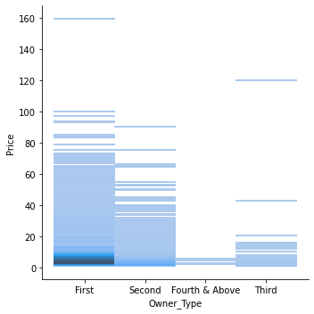

```python
sns.displot(df, x="Owner_Type",y="Price")
```

### Linear Regression Model

```python
#building the linear regression model
X = df.drop(['Price', 'Name', 'Location', 'Fuel_Type', 'Owner_Type', 'Transmission'], axis=1)
y = df[['Price']]
```

```python
# split the dataset into test and train data set
X_train, X_test, y_train, y_test = train_test_split(X, y, test_size=0.30, random_state=1)
```

```python
regression_model = LinearRegression()
regression_model.fit(X_train, y_train)
```

```
LinearRegression()
```

```python
for idx, col_name in enumerate(X_train.columns):
    print("The coefficient for {} is {}".format(col_name, regression_model.coef_[0][idx]))
```

```
The coefficient for Year is 1.0497975199271834
The coefficient for Kilometers_Driven is 2.1927634509165326e-06
The coefficient for Mileage is -0.006703265714789779
The coefficient for Engine is 0.0024280362189747057
The coefficient for Power is 0.13794777083887053
The coefficient for Seats is -0.9497943578609845
```

```python
intercept = regression_model.intercept_[0]
print(" Intercept of model is {}".format(intercept))
```

```
 Intercept of model is -2118.6652103050587
```

```python
regression_model.score(X_train, y_train)
```

```
0.6767334310816527
```

```python
regression_model.score(X_test, y_test)
```

```
0.7014330404016739
```

```python
from sklearn.preprocessing import PolynomialFeatures
from sklearn import linear_model

poly = PolynomialFeatures(degree=2, interaction_only=True)
X_train2 = poly.fit_transform(X_train)
X_test2 = poly.fit_transform(X_test)

poly_clf = linear_model.LinearRegression()

poly_clf.fit(X_train2, y_train)

y_pred = poly_clf.predict(X_test2)

print(poly_clf.score(X_train2, y_train))
```

```
0.8018675900135416
```

```python
print(poly_clf.score(X_test2, y_test))
```

```
0.8207535495752611
```

```python
print(X_train.shape)
print(X_train2.shape)
```

```
(4110, 6)
(4110, 22)
```